# Risk Factor Analysis

## Outcome Variable

**Outcome Variable:** swasted

## Predictor Variables

**Intervention Variable:** exclfeed3

**Adjustment Set:**

unadjusted

## Stratifying Variables

The analysis was stratified on these variable(s):

- agecat
- studyid
- country

## Data Summary

| agecat | studyid | country | exclfeed3 | swasted | n_cell | n |
| --- | --- | --- | --- | --- | --- | --- |
| Birth | ki0047075b-MAL-ED | BANGLADESH | 0 | 0 | 60 | 227 |
| Birth | ki0047075b-MAL-ED | BANGLADESH | 0 | 1 | 3 | 227 |
| Birth | ki0047075b-MAL-ED | BANGLADESH | 1 | 0 | 159 | 227 |
| Birth | ki0047075b-MAL-ED | BANGLADESH | 1 | 1 | 5 | 227 |
| Birth | ki0047075b-MAL-ED | BRAZIL | 0 | 0 | 112 | 177 |
| Birth | ki0047075b-MAL-ED | BRAZIL | 0 | 1 | 0 | 177 |
| Birth | ki0047075b-MAL-ED | BRAZIL | 1 | 0 | 65 | 177 |
| Birth | ki0047075b-MAL-ED | BRAZIL | 1 | 1 | 0 | 177 |
| Birth | ki0047075b-MAL-ED | INDIA | 0 | 0 | 70 | 193 |
| Birth | ki0047075b-MAL-ED | INDIA | 0 | 1 | 2 | 193 |
| Birth | ki0047075b-MAL-ED | INDIA | 1 | 0 | 116 | 193 |
| Birth | ki0047075b-MAL-ED | INDIA | 1 | 1 | 5 | 193 |
| Birth | ki0047075b-MAL-ED | NEPAL | 0 | 0 | 104 | 166 |
| Birth | ki0047075b-MAL-ED | NEPAL | 0 | 1 | 2 | 166 |
| Birth | ki0047075b-MAL-ED | NEPAL | 1 | 0 | 58 | 166 |
| Birth | ki0047075b-MAL-ED | NEPAL | 1 | 1 | 2 | 166 |
| Birth | ki0047075b-MAL-ED | PERU | 0 | 0 | 201 | 265 |
| Birth | ki0047075b-MAL-ED | PERU | 0 | 1 | 0 | 265 |
| Birth | ki0047075b-MAL-ED | PERU | 1 | 0 | 64 | 265 |
| Birth | ki0047075b-MAL-ED | PERU | 1 | 1 | 0 | 265 |
| Birth | ki0047075b-MAL-ED | SOUTH AFRICA | 0 | 0 | 198 | 231 |
| Birth | ki0047075b-MAL-ED | SOUTH AFRICA | 0 | 1 | 1 | 231 |
| Birth | ki0047075b-MAL-ED | SOUTH AFRICA | 1 | 0 | 32 | 231 |
| Birth | ki0047075b-MAL-ED | SOUTH AFRICA | 1 | 1 | 0 | 231 |
| Birth | ki0047075b-MAL-ED | TANZANIA, UNITED REPUBLIC OF | 0 | 0 | 75 | 114 |
| Birth | ki0047075b-MAL-ED | TANZANIA, UNITED REPUBLIC OF | 0 | 1 | 1 | 114 |
| Birth | ki0047075b-MAL-ED | TANZANIA, UNITED REPUBLIC OF | 1 | 0 | 38 | 114 |
| Birth | ki0047075b-MAL-ED | TANZANIA, UNITED REPUBLIC OF | 1 | 1 | 0 | 114 |
| Birth | ki1000108-CMC-V-BCS-2002 | INDIA | 0 | 0 | 0 | 4 |
| Birth | ki1000108-CMC-V-BCS-2002 | INDIA | 0 | 1 | 0 | 4 |

[output cut: 146 more lines]

The following strata were considered:

- agecat: 24 months, studyid: ki0047075b-MAL-ED, country: BANGLADESH
- agecat: 24 months, studyid: ki0047075b-MAL-ED, country: BRAZIL
- agecat: 24 months, studyid: ki0047075b-MAL-ED, country: INDIA
- agecat: 24 months, studyid: ki0047075b-MAL-ED, country: NEPAL
- agecat: 24 months, studyid: ki0047075b-MAL-ED, country: PERU
- agecat: 24 months, studyid: ki0047075b-MAL-ED, country: SOUTH AFRICA
- agecat: 24 months, studyid: ki0047075b-MAL-ED, country: TANZANIA, UNITED REPUBLIC OF
- agecat: 24 months, studyid: ki1000108-CMC-V-BCS-2002, country: INDIA
- agecat: 24 months, studyid: ki1000108-IRC, country: INDIA
- agecat: 24 months, studyid: ki1017093b-PROVIDE, country: BANGLADESH
- agecat: 24 months, studyid: ki1101329-Keneba, country: GAMBIA
- agecat: 24 months, studyid: ki1113344-GMS-Nepal, country: NEPAL
- agecat: 24 months, studyid: kiGH5241-JiVitA-3, country: BANGLADESH
- agecat: 24 months, studyid: kiGH5241-JiVitA-4, country: BANGLADESH
- agecat: 6 months, studyid: ki0047075b-MAL-ED, country: BANGLADESH
- agecat: 6 months, studyid: ki0047075b-MAL-ED, country: BRAZIL
- agecat: 6 months, studyid: ki0047075b-MAL-ED, country: INDIA
- agecat: 6 months, studyid: ki0047075b-MAL-ED, country: NEPAL
- agecat: 6 months, studyid: ki0047075b-MAL-ED, country: PERU
- agecat: 6 months, studyid: ki0047075b-MAL-ED, country: SOUTH AFRICA
- agecat: 6 months, studyid: ki0047075b-MAL-ED, country: TANZANIA, UNITED REPUBLIC OF
- agecat: 6 months, studyid: ki1000108-CMC-V-BCS-2002, country: INDIA
- agecat: 6 months, studyid: ki1000108-IRC, country: INDIA
- agecat: 6 months, studyid: ki1000109-EE, country: PAKISTAN
- agecat: 6 months, studyid: ki1000304b-SAS-CompFeed, country: INDIA
- agecat: 6 months, studyid: ki1017093b-PROVIDE, country: BANGLADESH
- agecat: 6 months, studyid: ki1101329-Keneba, country: GAMBIA
- agecat: 6 months, studyid: ki1113344-GMS-Nepal, country: NEPAL
- agecat: 6 months, studyid: kiGH5241-JiVitA-3, country: BANGLADESH
- agecat: 6 months, studyid: kiGH5241-JiVitA-4, country: BANGLADESH
- agecat: Birth, studyid: ki0047075b-MAL-ED, country: BANGLADESH
- agecat: Birth, studyid: ki0047075b-MAL-ED, country: BRAZIL
- agecat: Birth, studyid: ki0047075b-MAL-ED, country: INDIA
- agecat: Birth, studyid: ki0047075b-MAL-ED, country: NEPAL
- agecat: Birth, studyid: ki0047075b-MAL-ED, country: PERU
- agecat: Birth, studyid: ki0047075b-MAL-ED, country: SOUTH AFRICA
- agecat: Birth, studyid: ki0047075b-MAL-ED, country: TANZANIA, UNITED REPUBLIC OF
- agecat: Birth, studyid: ki1000108-CMC-V-BCS-2002, country: INDIA
- agecat: Birth, studyid: ki1000108-IRC, country: INDIA
- agecat: Birth, studyid: ki1000109-EE, country: PAKISTAN
- agecat: Birth, studyid: ki1000304b-SAS-CompFeed, country: INDIA
- agecat: Birth, studyid: ki1101329-Keneba, country: GAMBIA
- agecat: Birth, studyid: kiGH5241-JiVitA-3, country: BANGLADESH
- agecat: Birth, studyid: kiGH5241-JiVitA-4, country: BANGLADESH

### Dropped Strata

Some strata were dropped due to rare outcomes:

- agecat: Birth, studyid: ki0047075b-MAL-ED, country: BANGLADESH
- agecat: Birth, studyid: ki0047075b-MAL-ED, country: BRAZIL
- agecat: Birth, studyid: ki0047075b-MAL-ED, country: INDIA
- agecat: Birth, studyid: ki0047075b-MAL-ED, country: NEPAL
- agecat: Birth, studyid: ki0047075b-MAL-ED, country: PERU
- agecat: Birth, studyid: ki0047075b-MAL-ED, country: SOUTH AFRICA
- agecat: Birth, studyid: ki0047075b-MAL-ED, country: TANZANIA, UNITED REPUBLIC OF
- agecat: Birth, studyid: ki1000108-CMC-V-BCS-2002, country: INDIA
- agecat: Birth, studyid: ki1000108-IRC, country: INDIA
- agecat: Birth, studyid: ki1000109-EE, country: PAKISTAN
- agecat: Birth, studyid: ki1000304b-SAS-CompFeed, country: INDIA
- agecat: Birth, studyid: kiGH5241-JiVitA-4, country: BANGLADESH
- agecat: 6 months, studyid: ki0047075b-MAL-ED, country: BANGLADESH
- agecat: 6 months, studyid: ki0047075b-MAL-ED, country: BRAZIL
- agecat: 6 months, studyid: ki0047075b-MAL-ED, country: INDIA
- agecat: 6 months, studyid: ki0047075b-MAL-ED, country: NEPAL
- agecat: 6 months, studyid: ki0047075b-MAL-ED, country: PERU
- agecat: 6 months, studyid: ki0047075b-MAL-ED, country: SOUTH AFRICA
- agecat: 6 months, studyid: ki0047075b-MAL-ED, country: TANZANIA, UNITED REPUBLIC OF
- agecat: 6 months, studyid: ki1000108-CMC-V-BCS-2002, country: INDIA
- agecat: 6 months, studyid: ki1000108-IRC, country: INDIA
- agecat: 6 months, studyid: ki1000109-EE, country: PAKISTAN
- agecat: 6 months, studyid: ki1000304b-SAS-CompFeed, country: INDIA
- agecat: 6 months, studyid: ki1017093b-PROVIDE, country: BANGLADESH
- agecat: 6 months, studyid: ki1113344-GMS-Nepal, country: NEPAL
- agecat: 6 months, studyid: kiGH5241-JiVitA-4, country: BANGLADESH
- agecat: 24 months, studyid: ki0047075b-MAL-ED, country: BANGLADESH
- agecat: 24 months, studyid: ki0047075b-MAL-ED, country: BRAZIL
- agecat: 24 months, studyid: ki0047075b-MAL-ED, country: INDIA
- agecat: 24 months, studyid: ki0047075b-MAL-ED, country: NEPAL
- agecat: 24 months, studyid: ki0047075b-MAL-ED, country: PERU
- agecat: 24 months, studyid: ki0047075b-MAL-ED, country: SOUTH AFRICA
- agecat: 24 months, studyid: ki0047075b-MAL-ED, country: TANZANIA, UNITED REPUBLIC OF
- agecat: 24 months, studyid: ki1000108-CMC-V-BCS-2002, country: INDIA
- agecat: 24 months, studyid: ki1000108-IRC, country: INDIA
- agecat: 24 months, studyid: ki1017093b-PROVIDE, country: BANGLADESH
- agecat: 24 months, studyid: ki1101329-Keneba, country: GAMBIA
- agecat: 24 months, studyid: ki1113344-GMS-Nepal, country: NEPAL
- agecat: 24 months, studyid: kiGH5241-JiVitA-4, country: BANGLADESH

## Methods Detail

We’re interested in the causal parameters $E[Y_a]$ for all values of $a \in \mathcal{A}$. These parameters represent the mean outcome if, possibly contrary to fact, we intervened to set all units to have $A=a$. Under the randomization and positivity assumptions, these are identified by the statistical parameters $\psi_a=E_W[E_{Y|A,W}(Y|A=a,W)]$. In addition, we’re interested in the mean of $Y$, $E[Y]$ under no intervention (the observed mean). We will estimate these parameters by using SuperLearner to fit the relevant likelihood factors – $E_{Y|A,W}(Y|A=a,W)$ and $p(A=a|W)$, and then updating our likelihood fit using a joint TMLE.

For unadjusted analyses ($W=\{\}$), initial likelihoods were estimated using Lrnr_glm to estimate the simple $E(Y|A)$ and Lrnr_mean to estimate $p(A)$. For adjusted analyses, a small library containing Lrnr_glmnet, Lrnr_xgboost, and Lrnr_mean was used.

Having estimated these parameters, we will then use the delta method to estimate relative risks and attributable risks relative to a prespecified baseline level of $A$.

# Results Detail

## Results Plots

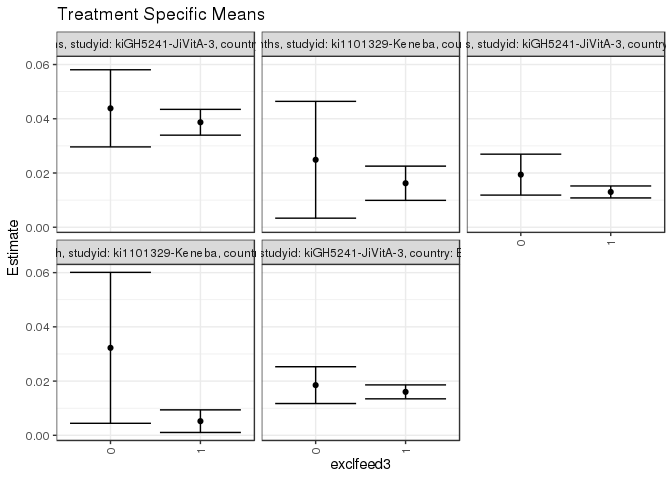

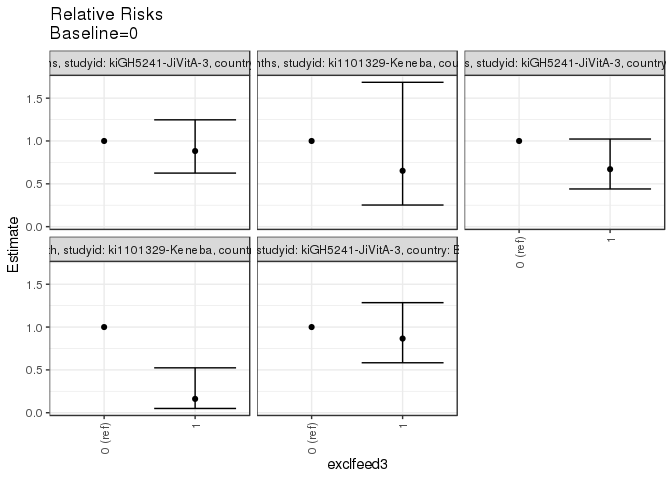

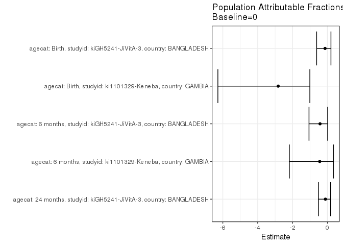

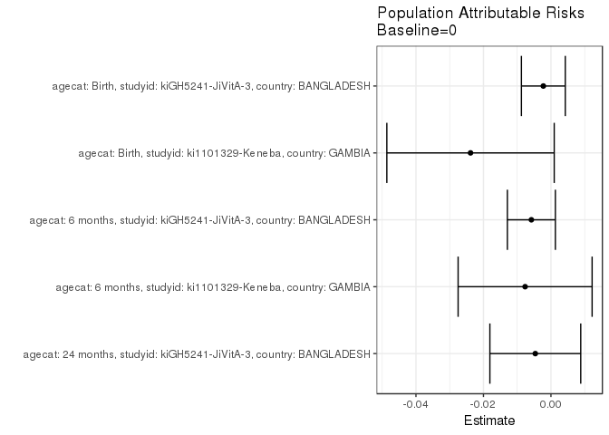

## Results Table

### Parameter: TSM

| agecat | studyid | country | intervention_level | baseline_level | estimate | ci_lower | ci_upper |
| --- | --- | --- | --- | --- | --- | --- | --- |
| Birth | ki1101329-Keneba | GAMBIA | 0 | NA | 0.0322581 | 0.0044323 | 0.0600839 |
| Birth | ki1101329-Keneba | GAMBIA | 1 | NA | 0.0052174 | 0.0010520 | 0.0093828 |
| Birth | kiGH5241-JiVitA-3 | BANGLADESH | 0 | NA | 0.0185053 | 0.0117211 | 0.0252896 |
| Birth | kiGH5241-JiVitA-3 | BANGLADESH | 1 | NA | 0.0160221 | 0.0134477 | 0.0185966 |
| 6 months | ki1101329-Keneba | GAMBIA | 0 | NA | 0.0248756 | 0.0033383 | 0.0464129 |
| 6 months | ki1101329-Keneba | GAMBIA | 1 | NA | 0.0162232 | 0.0099138 | 0.0225326 |
| 6 months | kiGH5241-JiVitA-3 | BANGLADESH | 0 | NA | 0.0193980 | 0.0118510 | 0.0269450 |
| 6 months | kiGH5241-JiVitA-3 | BANGLADESH | 1 | NA | 0.0130099 | 0.0108066 | 0.0152132 |
| 24 months | kiGH5241-JiVitA-3 | BANGLADESH | 0 | NA | 0.0438490 | 0.0296283 | 0.0580696 |
| 24 months | kiGH5241-JiVitA-3 | BANGLADESH | 1 | NA | 0.0387080 | 0.0339528 | 0.0434631 |

### Parameter: E(Y)

| agecat | studyid | country | intervention_level | baseline_level | estimate | ci_lower | ci_upper |
| --- | --- | --- | --- | --- | --- | --- | --- |
| Birth | ki1101329-Keneba | GAMBIA | NA | NA | 0.0084291 | 0.0034671 | 0.0133912 |
| Birth | kiGH5241-JiVitA-3 | BANGLADESH | NA | NA | 0.0162526 | 0.0138117 | 0.0186936 |
| 6 months | ki1101329-Keneba | GAMBIA | NA | NA | 0.0172216 | 0.0111106 | 0.0233326 |
| 6 months | kiGH5241-JiVitA-3 | BANGLADESH | NA | NA | 0.0135975 | 0.0114712 | 0.0157238 |
| 24 months | kiGH5241-JiVitA-3 | BANGLADESH | NA | NA | 0.0392157 | 0.0346894 | 0.0437419 |

### Parameter: RR

| agecat | studyid | country | intervention_level | baseline_level | estimate | ci_lower | ci_upper |
| --- | --- | --- | --- | --- | --- | --- | --- |
| Birth | ki1101329-Keneba | GAMBIA | 0 | 0 | 1.0000000 | 1.0000000 | 1.0000000 |
| Birth | ki1101329-Keneba | GAMBIA | 1 | 0 | 0.1617391 | 0.0499302 | 0.5239226 |
| Birth | kiGH5241-JiVitA-3 | BANGLADESH | 0 | 0 | 1.0000000 | 1.0000000 | 1.0000000 |
| Birth | kiGH5241-JiVitA-3 | BANGLADESH | 1 | 0 | 0.8658118 | 0.5834165 | 1.2848969 |
| 6 months | ki1101329-Keneba | GAMBIA | 0 | 0 | 1.0000000 | 1.0000000 | 1.0000000 |
| 6 months | ki1101329-Keneba | GAMBIA | 1 | 0 | 0.6521739 | 0.2524399 | 1.6848792 |
| 6 months | kiGH5241-JiVitA-3 | BANGLADESH | 0 | 0 | 1.0000000 | 1.0000000 | 1.0000000 |
| 6 months | kiGH5241-JiVitA-3 | BANGLADESH | 1 | 0 | 0.6706824 | 0.4397679 | 1.0228462 |
| 24 months | kiGH5241-JiVitA-3 | BANGLADESH | 0 | 0 | 1.0000000 | 1.0000000 | 1.0000000 |
| 24 months | kiGH5241-JiVitA-3 | BANGLADESH | 1 | 0 | 0.8827564 | 0.6249835 | 1.2468471 |

### Parameter: PAR

| agecat | studyid | country | intervention_level | baseline_level | estimate | ci_lower | ci_upper |
| --- | --- | --- | --- | --- | --- | --- | --- |
| Birth | ki1101329-Keneba | GAMBIA | 0 | NA | -0.0238289 | -0.0486275 | 0.0009696 |
| Birth | kiGH5241-JiVitA-3 | BANGLADESH | 0 | NA | -0.0022527 | -0.0087531 | 0.0042477 |
| 6 months | ki1101329-Keneba | GAMBIA | 0 | NA | -0.0076540 | -0.0275074 | 0.0121994 |
| 6 months | kiGH5241-JiVitA-3 | BANGLADESH | 0 | NA | -0.0058005 | -0.0129119 | 0.0013109 |
| 24 months | kiGH5241-JiVitA-3 | BANGLADESH | 0 | NA | -0.0046333 | -0.0180952 | 0.0088286 |

### Parameter: PAF

| agecat | studyid | country | intervention_level | baseline_level | estimate | ci_lower | ci_upper |
| --- | --- | --- | --- | --- | --- | --- | --- |
| Birth | ki1101329-Keneba | GAMBIA | 0 | NA | -2.8269795 | -6.2837872 | -1.0107358 |
| Birth | kiGH5241-JiVitA-3 | BANGLADESH | 0 | NA | -0.1386049 | -0.6206126 | 0.2000426 |
| 6 months | ki1101329-Keneba | GAMBIA | 0 | NA | -0.4444444 | -2.1858175 | 0.3450913 |
| 6 months | kiGH5241-JiVitA-3 | BANGLADESH | 0 | NA | -0.4265864 | -1.0585212 | 0.0113540 |
| 24 months | kiGH5241-JiVitA-3 | BANGLADESH | 0 | NA | -0.1181486 | -0.5202446 | 0.1775953 |